# HomeworkW47

Sascha Berg

2021/11/30

```r
library(tidyverse)
```

```r
Western_Europe <- read_csv("data/homicide-rates-across-western-europe.csv")
```

## 1) the column name Western_Europe$`Homicide rate in Europe over long-term (per 100,000) is not very easy to work with. Relabel it to ‘homicides_per_100k’ inside R after loading the dataset and then edit all the ggplots.

Renaming

```r
names(Western_Europe)[4] <- 'Homicide_per_100k'
```

Editing the plots

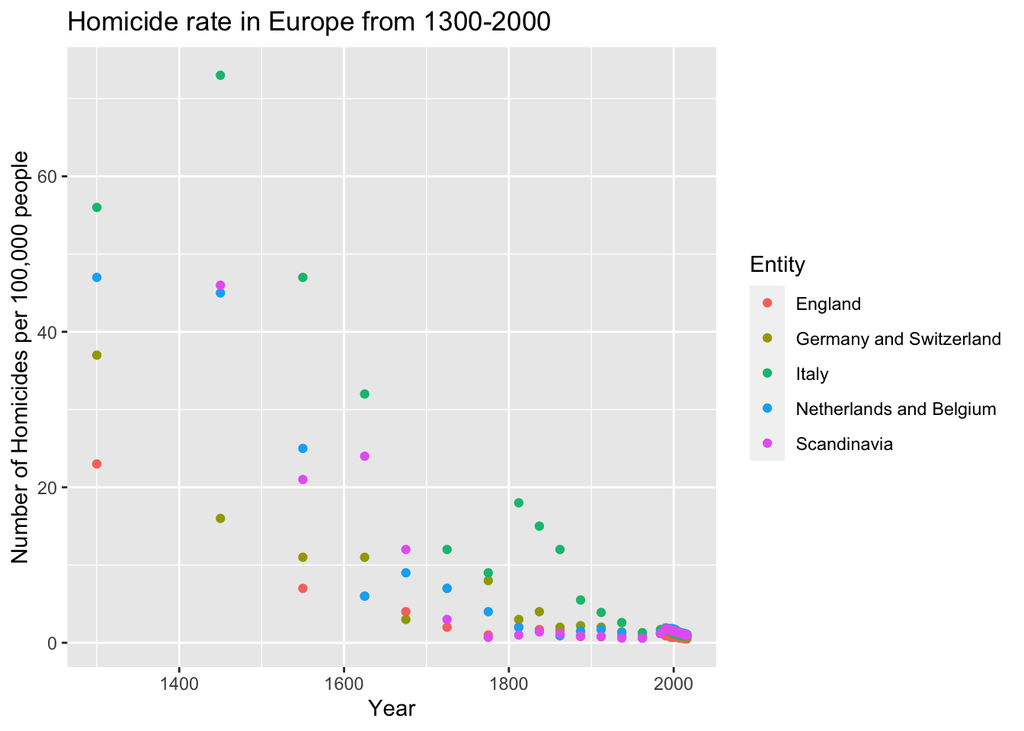

```r
ggplot(data = Western_Europe) +
  geom_point(mapping = aes(x = Year,
                           y = Western_Europe$Homicide_per_100k,
                           color = Entity)) +
  labs(x = "Year",
       y = "Number of Homicides per 100,000 people",
       title = "Homicide rate in Europe from 1300-2000")
```

New plot

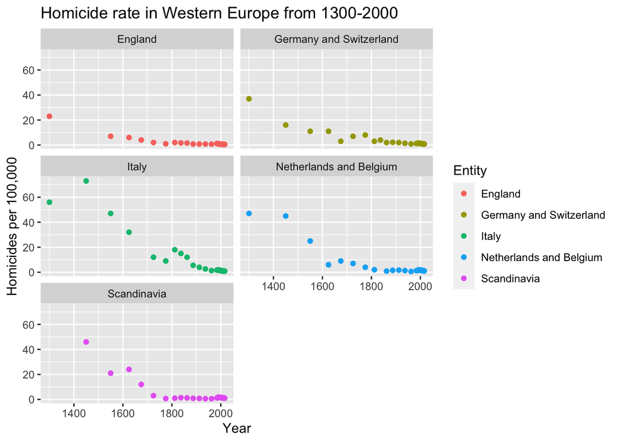

```r
ggplot(data = Western_Europe) +
  geom_point(mapping = aes(x = Year,
                           y = Western_Europe$Homicide_per_100k,
                           color = Entity)) +
  facet_wrap(~ Entity, nrow = 3) +
  labs(x = "Year",
       y = "Homicides per 100,000",
       title = "Homicide rate in Western Europe from 1300-2000")
```

## 2) The basic plot and following facet-plot (combination plot) is great, but geom_point - a scatterplot - is not the best choice for showing long-term data. Can you change both plots to more suitable type of rendering?

#Creating a line plot, as it is easier to se longterm trends, using: geom_line

Plot with all the data together

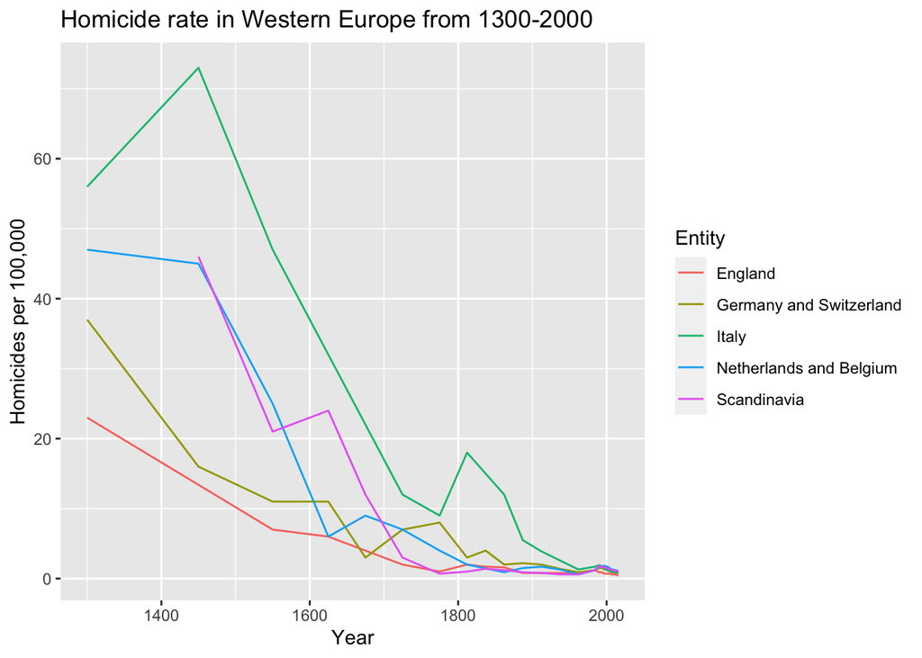

```r
ggplot(data = Western_Europe) +
  geom_line(mapping = aes(x = Year, y = Western_Europe$'Homicide_per_100k',color = Entity )) +
  labs(x = "Year", y = "Homicides per 100,000", title = "Homicide rate in Western Europe from 1300-2000")
```

Plot with seperate graphs divided by country.

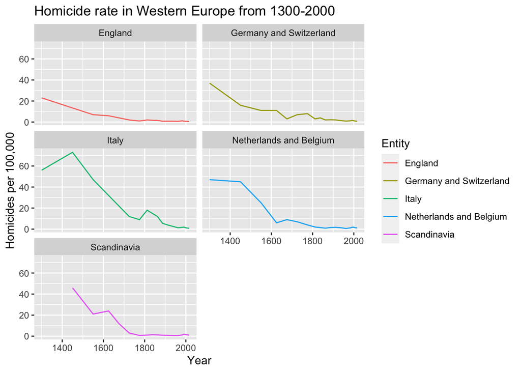

```r
ggplot(data = Western_Europe)+
  geom_line(mapping = aes(x = Year, y = Western_Europe$Homicide_per_100k, color = Entity))+
  facet_wrap(~ Entity, nrow = 3) +
  labs(x = "Year",
       y = "Homicides per 100,000",
       title = "Homicide rate in Western Europe from 1300-2000")
```

## 3) Can you change the facet “layout” to two columns and three rows so that the trends are easier to see?

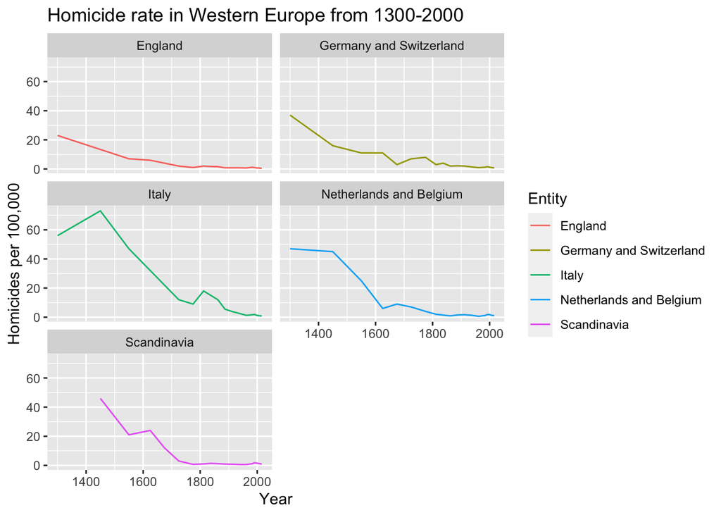

```r
ggplot(data = Western_Europe)+
  geom_line(mapping = aes(x = Year, y = Western_Europe$Homicide_per_100k, color = Entity))+
  facet_wrap(~ Entity, nrow = 3, ncol = 2) +
  labs(x = "Year",
       y = "Homicides per 100,000",
       title = "Homicide rate in Western Europe from 1300-2000")
```

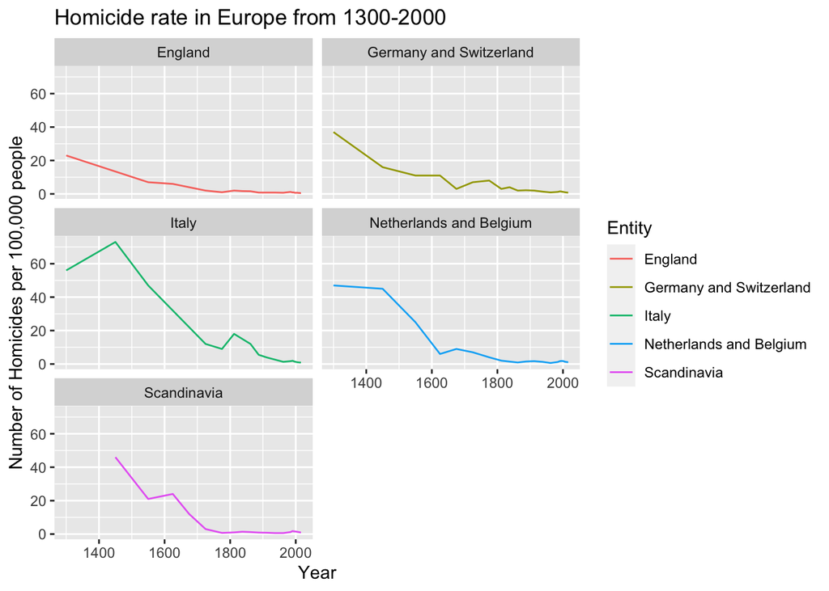

```r
ggplot(data = Western_Europe) +
  geom_line(mapping = aes(x = Year,
                          y = Western_Europe$Homicide_per_100k,
                          color = Entity)) +
  facet_wrap(~ Entity, nrow = 3, ncol = 2) +
  labs(x = "Year",
       y = "Number of Homicides per 100,000 people",
       title = "Homicide rate in Europe from 1300-2000")
```

## 4) Move the legend from the current position on the side to below the facets, and label it “Country” instead of “Entity”.

Renaming to “Country” instead of “Entity”

```r
names(Western_Europe)[1] <- 'Country'
```

Changing the layout

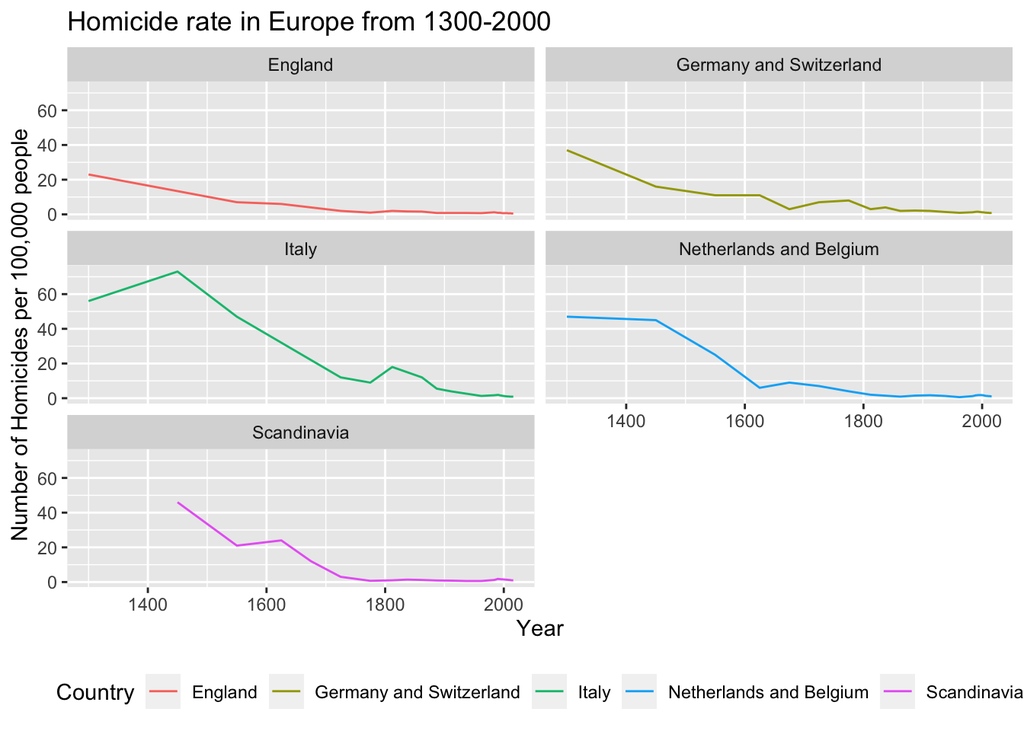

```r
ggplot(data = Western_Europe) +
  geom_line(mapping = aes(x = Year,
                          y = Western_Europe$Homicide_per_100k,
                          color = Country)) +
  facet_wrap(~ Country, nrow = 3, ncol = 2) +
  labs(x = "Year",
       y = "Number of Homicides per 100,000 people",
       title = "Homicide rate in Europe from 1300-2000")+
  theme(legend.position = "bottom")
```

## 5) Add a floating table of contents to your Rmarkdown document, provide informative chunk-names to all your R chunks, and automatically generate a timestamp to show when the document was last updated. (Hint: check the Rmarkdown episode in our Data Carpentry tutorial)

I used the following code in the header:

title: “HomeworkW47” author: “Sascha Berg” date: “2021/11/30” output: html_document: toc: TRUE toc_float: TRUE

## 6) Fill in the empty code chunk with a ggplot of your Danish kings: loading the data, calculating the mid-year, and plotting the duration of reign (y axis) over the mid-year (x axis), using geom_smooth()

Loading the Kings file into R

```r
Kings <- read_delim("Kings.csv")
```

Calculating the mid-year

Firstly, creating a column showing duration of reign

```r
Kings$duration <- Kings$Reign_end-Kings$Reign_start
```

Afterwards calculating the mid-year

```r
Kings$midyear <- round(Kings$Reign_start+(Kings$duration/2),0)
```

Plotting it

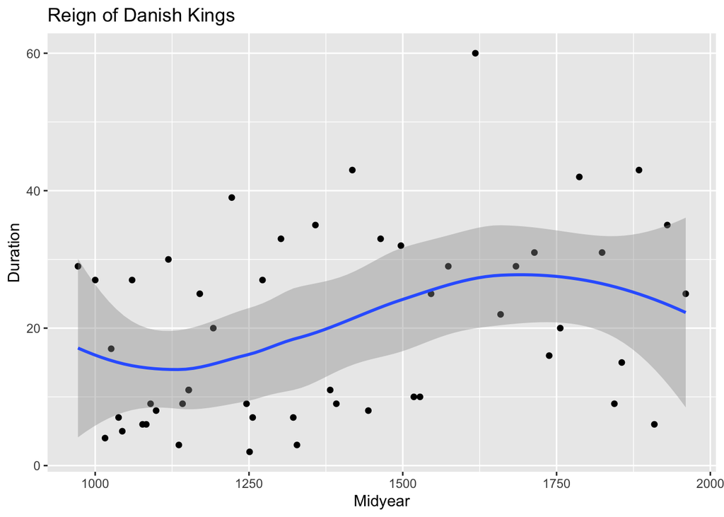

```r
ggplot(data = Kings)+
  geom_point(mapping = aes(x = midyear, y = Kings$duration))+
  geom_smooth(mapping = aes(x = midyear, y = Kings$duration))+
   labs(x = "Midyear", y = "Duration", title = "Reign of Danish Kings")
```

## 7) Comment briefly what is your opinion on the basis of the data visualisations: are we more civilized today?

My opinion is that by plotting the data into grpahs it is much earsier to see wheter we have become more civilized. My opinion, formed by looking at the graphs is that we have become more civilized, because the graphs have declined.